# Homework 1

## Gianni Spiga

### For STA 209, Fall 2023

- I discussed approaches and methodology to these problems with Jonas Kempf and Niraj Bangari

```python
import numpy as np
import matplotlib.pyplot as plt
```

# Problem 1

## a.)

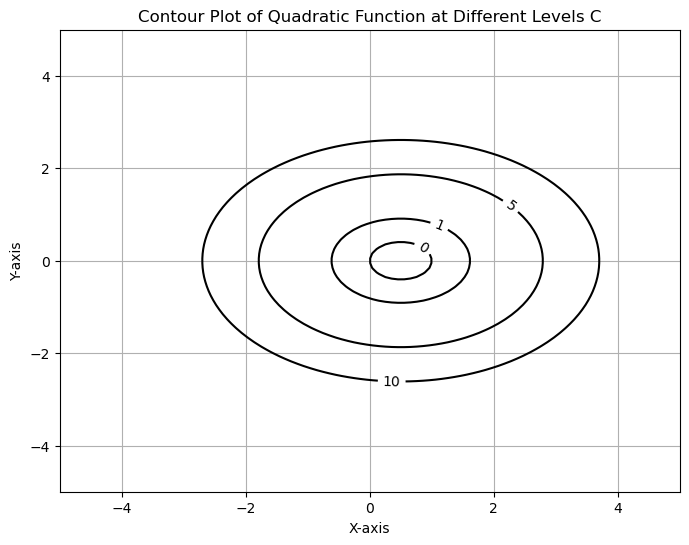

```python
def problem_1_quad_func(x,y, alpha, beta):
    return 1/2 * (alpha * x**2 + beta * y ** 2) - x

# Generate evenly spaced sequences of numbers
x = np.linspace(-5, 5, num = 100)
y = np.linspace(-5, 5, num = 100)

x, y = np.meshgrid(x, y)

# Example case a, alpha, beta > 0, we will use alpha = 2, beta = 3
f_of_x_y  = problem_1_quad_func(x, y, 2,3)
f_of_x_y

# Specify the levels you want to plot
levels = [-10, -5, -1, 0, 1, 5, 10]

# Create a contour plot
plt.figure(figsize=(8, 6))
contour = plt.contour(x, y, f_of_x_y, levels=levels, colors='k')
plt.clabel(contour, inline=1, fontsize=10)

# Add labels, title, and a color bar
plt.xlabel('X-axis')
plt.ylabel('Y-axis')
plt.title('Contour Plot of Quadratic Function at Different Levels C')
#plt.colorbar()

# Show the plot
plt.grid(True)
plt.show()
```

Here any negative values would have levels sets = $\emptyset$

## b.)

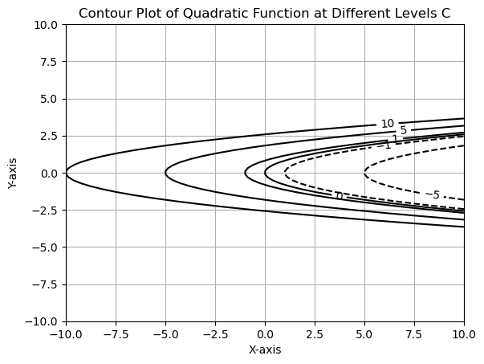

```python
# Generate evenly spaced sequences of numbers
x = np.linspace(-10, 10, num = 100)
y = np.linspace(-10, 10, num = 100)

x, y = np.meshgrid(x, y)

# Example case b, alpha = 0, beta > 0, we will use alpha = 2, beta = 3
f_of_x_y  = problem_1_quad_func(x, y, alpha=0,beta = 3)
f_of_x_y

# Create a contour plot
contour = plt.contour(x, y, f_of_x_y, levels=levels, colors='k')
plt.clabel(contour, inline=1, fontsize=10)

# Add labels, title, and a color bar
plt.xlabel('X-axis')
plt.ylabel('Y-axis')
plt.title('Contour Plot of Quadratic Function at Different Levels C')
#plt.colorbar()

# Show the plot
plt.grid(True)
plt.show()
```

## c.)

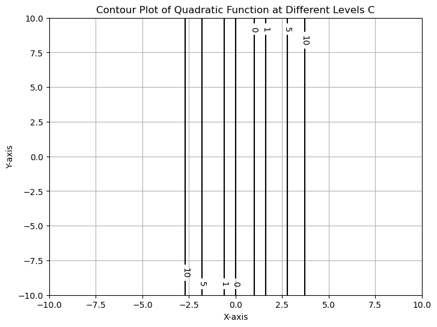

```python
# Generate evenly spaced sequences of numbers
x = np.linspace(-10, 10, num = 100)
y = np.linspace(-10, 10, num = 100)

x, y = np.meshgrid(x, y)

# Example case c, alpha > 0, beta = 0, we will use alpha = 2, beta = 0
f_of_x_y  = problem_1_quad_func(x, y, alpha=2,beta = 0)
f_of_x_y

# Create a contour plot
plt.figure(figsize=(8, 6))
contour = plt.contour(x, y, f_of_x_y, levels=levels, colors='k')
plt.clabel(contour, inline=1, fontsize=10)

# Add labels, title, and a color bar
plt.xlabel('X-axis')
plt.ylabel('Y-axis')
plt.title('Contour Plot of Quadratic Function at Different Levels C')
#plt.colorbar()

# Show the plot
plt.grid(True)
plt.show()
```

Here any negative values would have levels sets = $\emptyset$

## d.)

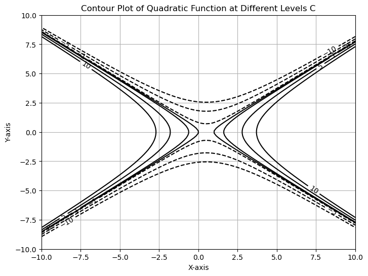

```python
# Generate evenly spaced sequences of numbers
x = np.linspace(-10, 10, num = 100)
y = np.linspace(-10, 10, num = 100)

x, y = np.meshgrid(x, y)

# Example case d, alpha > 0, beta < 0, we will use alpha = 2, beta = -3
f_of_x_y  = problem_1_quad_func(x, y, alpha=2,beta = -3)
f_of_x_y

# Create a contour plot
plt.figure(figsize=(8, 6))
contour = plt.contour(x, y, f_of_x_y, levels=levels, colors='k')
plt.clabel(contour, inline=1, fontsize=10)

# Add labels, title, and a color bar
plt.xlabel('X-axis')
plt.ylabel('Y-axis')
plt.title('Contour Plot of Quadratic Function at Different Levels C')

# Show the plot
plt.grid(True)
plt.show()
```

For the minimizer for case a.), we have: $$ \begin{align*} \frac{\partial f}{\partial x} &= \alpha x - 1 \\ 0 &= \alpha x - 1 \\ \frac{1}{\alpha} &= x \end{align*} $$ and $$ \begin{align*} \frac{\partial f}{\partial y} &= \beta y \\ 0 &= \beta y \\ 0 &= y \\ \end{align*} $$ For the minimizing point $(\frac{1}{\alpha}, 0)$.

For the minimizer for case b.), we have: $$ \begin{align*} \frac{\partial f}{\partial x} &= - 1 \\ 0 &= - 1 \\ \text{No minimum exists} \end{align*} $$ and $$ \begin{align*} \frac{\partial f}{\partial y} &= \beta y \\ 0 &= \beta y\\ 0 &= y\\ \end{align*} $$

For the minimizer for case c.), we have: $$ \begin{align*} \frac{\partial f}{\partial x} &= \alpha x - 1 \\ 0 &= \alpha x - 1 \\ \frac{1}{\alpha} &= x \end{align*} $$ and $$ \begin{align*} \frac{\partial f}{\partial y} &= 0 \\ 0 &= 0\\ \end{align*} $$ For the minimizing point $(\frac{1}{\alpha}, y)$.

## Problem 2

$$ g(z) = \frac{1}{2}z^TQz - c^Tz $$

### a.) What is $\nabla g(z)$ as function of z? What is $||\nabla g(z)||^2$?

$$ \begin{align*} \nabla g(z) &= Qz - c \\ ||\nabla g(z)||_2 &= \sqrt{(Qz - c)^T(Qz - c)} \end{align*} $$

### b.) What is $\nabla g(z)$ as $z = [0, 0]^T$?

$$ \begin{align*} \nabla g(z) &= Q[0, 0]^T - c \\ \nabla g(z) &= - c \\ \end{align*} $$

### c.) What is $\nabla g(z)$ as $z = [0, 1]^T$?

$$ \begin{align*} \nabla g(z) &= Q[0, 1]^T - c \\ \nabla g(z) &= [q_{12} , q_{22}]^T - [c_1, c_2]^T \\ \nabla g(z) &= [q_{12}-c_1, q_{22} - c_2]^T \\ \end{align*} $$

### d.) What is $\nabla g(z)$ as $z = [1, 0]^T$?

$$ \begin{align*} \nabla g(z) &= Q[1, 0]^T - c \\ \nabla g(z) &= [q_{11} , q_{21}]^T - [c_1, c_2]^T \\ \nabla g(z) &= [q_{11} -c_1, q_{21}-c_1]^T \\ \end{align*} $$

### e.) What is $\nabla^2 g(z)$ as function of $z$?

$$ \begin{align*} \nabla g(z) &= Qz - c \\ \nabla^2 g(z) &= Q \\ \end{align*} $$

### f.) Define $h(z) = g(Hz)$ for some $H \in \mathbb{R}^{2\times2} $

- i.) What is $\nabla h(z)$ as a function of z? What is $||h(z)||_2$?

$$ \begin{align*} h(z) &= \frac{1}{2}(Hz)^TQ(Hz) - c^T(Hz) \\ &= \frac{1}{2}z^TH^TQHz - c^THz \\ &\text{Let $\Lambda = H^TQH$}\\ &= \frac{1}{2}z^T \Lambda z - c^T(Hz) \\ \nabla h(z) &= \Lambda z - cH \\ \nabla h(z) &= H^TQH z - cH \\ ||\nabla h(z)||_2 &= \sqrt{(\Lambda z - cH)^T(\Lambda z - cH)} \\ ||\nabla h(z)||_2 &= \sqrt{(H^TQH z - cH)^T(H^TQH z - cH)} \\ \end{align*} $$

- ii.)

$$ \begin{align*} \nabla h(z) &= H^TQH z - cH \\ \nabla^2 h(z) &= H^TQH \\ \end{align*} $$

### g.)

- i. Determine the matrix $Q \in \mathbb{R}^{2\times2}$ and vector $c \in \mathbb{R}^2$ such that $f(x,y) = g(z)$ for $z = [x, y]^T$ for $f$ defined in Problem 1.

$$ \begin{align*} \frac{1}{2}(\alpha x^2 + \beta y^2) - x &= \frac{1}{2}[x, y] \begin{bmatrix} q_{11} & q_{12}\\ q_{21} & q_{22} \end{bmatrix}[x, y]^T - c [x, y]^T\\ &= \frac{1}{2}[x, y] \begin{bmatrix} \alpha & 0\\ 0 & \beta \end{bmatrix}[x, y]^T - [1,0] [x, y]^T \\ Q &= \begin{bmatrix} \alpha & 0\\ 0 & \beta \end{bmatrix} \\ c &= [1,0] \end{align*} $$

- ii. What are the eigenvectors and eigenvalues of matrix $Q$ in terms of $\alpha$ and $\beta$?

The eigenvalues of the matrix $Q$ are the values $\alpha$, $\beta$. Since the matrix $Q$ is diagonal, the eigenvectors are just the standard basis $[1, 0]^T$ and $[0,1]^T$.

- iii. Let $H = \begin{bmatrix} 0 & 1\\ 1 & 0 \end{bmatrix}$ with $Q$ and $c$ be the same as above. What is $h(z)$ in terms of $\alpha$ and $\beta$? Determine the level sets of $h(z)$ in all four regimes of $\alpha$ and $\beta$ described in problem 1.

$$ \begin{align*} h(z) &= \frac{1}{2}(Hz)^TQ(Hz) - c^T(Hz) \\ &= \frac{1}{2}(\begin{bmatrix} 0 & 1\\ 1 & 0 \end{bmatrix}z)^T \begin{bmatrix} \alpha & 0\\ 0 & \beta \end{bmatrix} (\begin{bmatrix} 0 & 1\\ 1 & 0 \end{bmatrix}z) - [1,0]^T(\begin{bmatrix} 0 & 1\\ 1 & 0 \end{bmatrix}z) \\ &= \frac{1}{2}[x, y]\begin{bmatrix} 0 & 1\\ 1 & 0 \end{bmatrix} \begin{bmatrix} \alpha & 0\\ 0 & \beta \end{bmatrix} \begin{bmatrix} 0 & 1\\ 1 & 0 \end{bmatrix}[x, y]^T - [1,0]^T(\begin{bmatrix} 0 & 1\\ 1 & 0 \end{bmatrix}[x, y]) \\ &= \frac{1}{2}[x, y]\begin{bmatrix} 0 & 1\\ 1 & 0 \end{bmatrix} \begin{bmatrix} \alpha & 0\\ 0 & \beta \end{bmatrix} \begin{bmatrix} 0 & 1\\ 1 & 0 \end{bmatrix}[x, y]^T - [1,0]^T(\begin{bmatrix} 0 & 1\\ 1 & 0 \end{bmatrix}[x, y]) \\ &= \frac{1}{2}[y, x] \begin{bmatrix} \alpha & 0\\ 0 & \beta \end{bmatrix} \begin{bmatrix} 0 & 1\\ 1 & 0 \end{bmatrix}[x, y]^T - [0,1]^T[x, y] \\ &= \frac{1}{2}[x \beta, y \alpha] [x, y]^T - y \\ &= \frac{1}{2}[\beta x^2 + \alpha y^2] - y\\ \end{align*} $$

For the inverse $H^{-1}$: $$ \begin{align*} H^{-1} &= \frac{1}{0*0 - 1*1}\begin{bmatrix} 0 & 1\\ 1 & 0 \end{bmatrix} &= \begin{bmatrix} 0 & -1\\ -1 & 0 \end{bmatrix} \end{align*} $$

For the level sets:

[figure not shown]

```python
def problem_2_quad_func(x,y, alpha, beta):
    return 1/2 * (beta * x**2 + alpha * y ** 2) - y

# Generate evenly spaced sequences of numbers
x = np.linspace(-5, 5, num = 100)
y = np.linspace(-5, 5, num = 100)

x, y = np.meshgrid(x, y)

# Example case a, alpha, beta > 0, we will use alpha = 2, beta = 3
f_of_x_y  = problem_1_quad_func(x, y, 2,3)
f_of_x_y

# Specify the levels you want to plot
levels = [-10, -5, -1, 0, 1, 5, 10]

# Create a contour plot
plt.figure(figsize=(8, 6))
contour = plt.contour(x, y, f_of_x_y, levels=levels, colors='k')
plt.clabel(contour, inline=1, fontsize=10)

# Add labels, title, and a color bar
plt.xlabel('X-axis')
plt.ylabel('Y-axis')
plt.title('Contour Plot of Quadratic Function at Different Levels C')
#plt.colorbar()

# Show the plot
plt.grid(True)
plt.show()
```

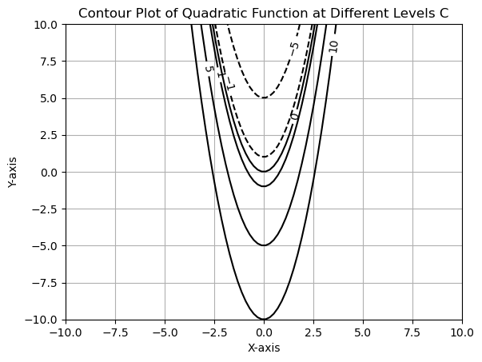

```python
# Generate evenly spaced sequences of numbers
x = np.linspace(-10, 10, num = 100)
y = np.linspace(-10, 10, num = 100)

x, y = np.meshgrid(x, y)

# Example case b, alpha = 0, beta > 0, we will use alpha = 2, beta = 3
f_of_x_y  = problem_2_quad_func(x, y, alpha=0,beta = 3)
f_of_x_y

# Create a contour plot
contour = plt.contour(x, y, f_of_x_y, levels=levels, colors='k')
plt.clabel(contour, inline=1, fontsize=10)

# Add labels, title, and a color bar
plt.xlabel('X-axis')
plt.ylabel('Y-axis')
plt.title('Contour Plot of Quadratic Function at Different Levels C')
#plt.colorbar()

# Show the plot
plt.grid(True)
plt.show()
```

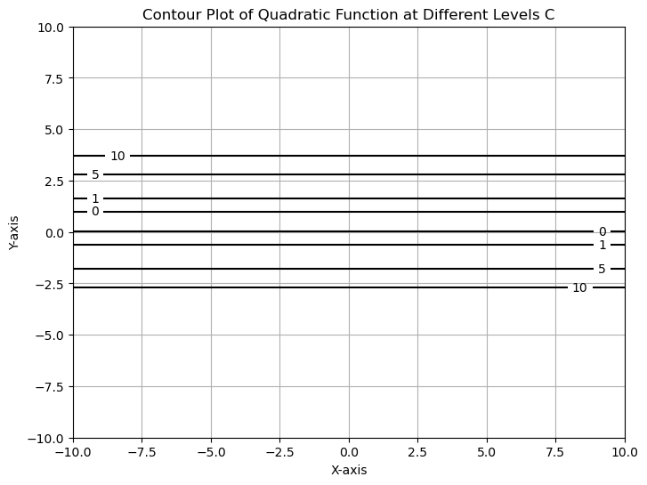

```python
# Generate evenly spaced sequences of numbers
x = np.linspace(-10, 10, num = 100)
y = np.linspace(-10, 10, num = 100)

x, y = np.meshgrid(x, y)

# Example case c, alpha > 0, beta = 0, we will use alpha = 2, beta = 0
f_of_x_y  = problem_2_quad_func(x, y, alpha=2,beta = 0)
f_of_x_y

# Create a contour plot
plt.figure(figsize=(8, 6))
contour = plt.contour(x, y, f_of_x_y, levels=levels, colors='k')
plt.clabel(contour, inline=1, fontsize=10)

# Add labels, title, and a color bar
plt.xlabel('X-axis')
plt.ylabel('Y-axis')
plt.title('Contour Plot of Quadratic Function at Different Levels C')
#plt.colorbar()

# Show the plot
plt.grid(True)
plt.show()
```

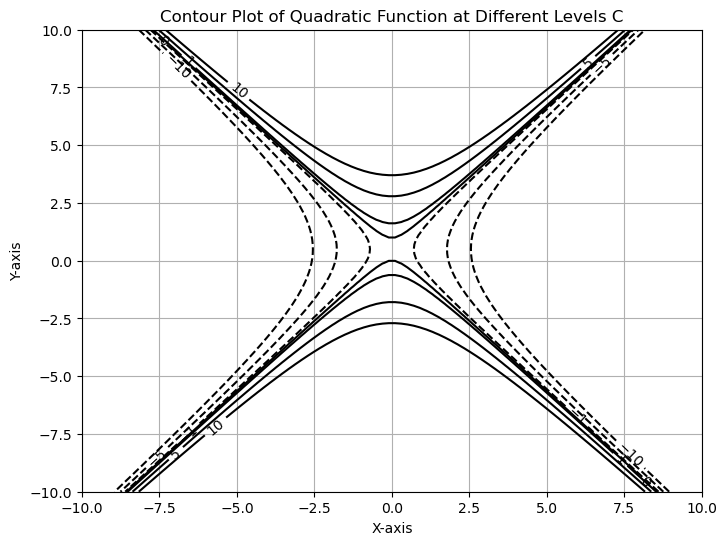

```python
# Generate evenly spaced sequences of numbers
x = np.linspace(-10, 10, num = 100)
y = np.linspace(-10, 10, num = 100)

x, y = np.meshgrid(x, y)

# Example case d, alpha > 0, beta < 0, we will use alpha = 2, beta = -3
f_of_x_y  = problem_2_quad_func(x, y, alpha=2,beta = -3)
f_of_x_y

# Create a contour plot
plt.figure(figsize=(8, 6))
contour = plt.contour(x, y, f_of_x_y, levels=levels, colors='k')
plt.clabel(contour, inline=1, fontsize=10)

# Add labels, title, and a color bar
plt.xlabel('X-axis')
plt.ylabel('Y-axis')
plt.title('Contour Plot of Quadratic Function at Different Levels C')

# Show the plot
plt.grid(True)
plt.show()
```

- iv. Let $H = \frac{1}{\sqrt{2}}\begin{bmatrix} 1 & -1\\ 1 & 1 \end{bmatrix}$ with $Q$ and $c$ be the same as above. What is $h(z)$ in terms of $\alpha$ and $\beta$? Determine the level sets of $h(z)$ in all four regimes of $\alpha$ and $\beta$ described in problem 1?

$$ \begin{align*} h(z) &= \frac{1}{2}(Hz)^TQ(Hz) - c^T(Hz) \\ &= \frac{1}{2}(\frac{1}{\sqrt{2}}\begin{bmatrix} 1 & -1\\ 1 & 1 \end{bmatrix}z)^T \begin{bmatrix} \alpha & 0\\ 0 & \beta \end{bmatrix} (\frac{1}{\sqrt{2}}\begin{bmatrix} 1 & -1\\ 1 & 1 \end{bmatrix}z) - [1,0]^T(\frac{1}{\sqrt{2}}\begin{bmatrix} 1 & -1\\ 1 & 1 \end{bmatrix}z) \\ &= \frac{1}{2}[x, y]\frac{1}{\sqrt{2}}\begin{bmatrix} 1 & -1\\ 1 & 1 \end{bmatrix}^T \begin{bmatrix} \alpha & 0\\ 0 & \beta \end{bmatrix} \frac{1}{\sqrt{2}}\begin{bmatrix} 1 & -1\\ 1 & 1 \end{bmatrix}[x, y]^T - \frac{1}{\sqrt{2}}[1,0][x-y, x+y]^T \\ &= \frac{1}{2}\frac{1}{\sqrt{2}}\frac{1}{\sqrt{2}}[x, y]\begin{bmatrix} 1 & 1\\ -1 & 1 \end{bmatrix} \begin{bmatrix} \alpha & 0\\ 0 & \beta \end{bmatrix} \begin{bmatrix} 1 & -1\\ 1 & 1 \end{bmatrix}[x, y]^T - \frac{1}{\sqrt{2}}(x-y) \\ &= \frac{1}{4}[x-y, x+y] \begin{bmatrix} \alpha & 0\\ 0 & \beta \end{bmatrix} \begin{bmatrix} 1 & -1\\ 1 & 1 \end{bmatrix}[x, y]^T - \frac{1}{\sqrt{2}}(x-y) \\ &= \frac{1}{4}[\alpha(x-y), \beta(x+y)] \begin{bmatrix} 1 & -1\\ 1 & 1 \end{bmatrix}[x, y]^T - \frac{1}{\sqrt{2}}(x-y) \\ &= \frac{1}{4}[\alpha(x-y) + \beta(x+y),-\alpha(x-y) + \beta(x+y)] [x, y]^T - \frac{1}{\sqrt{2}}(x-y) \\ &= \frac{1}{4}[x(\alpha(x-y) + \beta(x+y)) + y(-\alpha(x-y) + \beta(x+y))] - \frac{1}{\sqrt{2}}(x-y) \\ &= \frac{1}{4}[(\alpha+\beta)x^2 + 2(\beta - \alpha)xy + (\alpha + \beta)y^2] - \frac{1}{\sqrt{2}}(x-y) \\ \end{align*} $$

For the level sets:

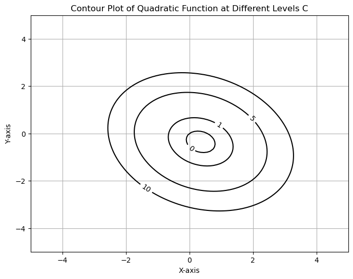

```python
def problem_2_new_quad_func(x,y, alpha, beta):
    return 1/4 * ((alpha + beta) * x**2 + 2*(beta - alpha) * x * y + (alpha + beta)*y ** 2) - (1/np.sqrt(2)) * (x - y)

# Generate evenly spaced sequences of numbers
x = np.linspace(-5, 5, num = 100)
y = np.linspace(-5, 5, num = 100)

x, y = np.meshgrid(x, y)

# Example case a, alpha, beta > 0, we will use alpha = 2, beta = 3
f_of_x_y  = problem_2_new_quad_func(x, y, 2,3)
f_of_x_y

# Specify the levels you want to plot
levels = [-10, -5, -1, 0, 1, 5, 10]

# Create a contour plot
plt.figure(figsize=(8, 6))
contour = plt.contour(x, y, f_of_x_y, levels=levels, colors='k')
plt.clabel(contour, inline=1, fontsize=10)

# Add labels, title, and a color bar
plt.xlabel('X-axis')
plt.ylabel('Y-axis')
plt.title('Contour Plot of Quadratic Function at Different Levels C')
#plt.colorbar()

# Show the plot
plt.grid(True)
plt.show()
```

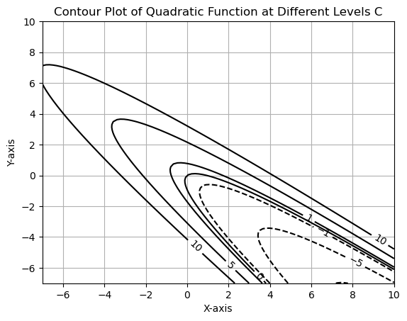

```python
# Generate evenly spaced sequences of numbers
x = np.linspace(-7, 10, num = 100)
y = np.linspace(-7, 10, num = 100)

x, y = np.meshgrid(x, y)

# Example case b, alpha = 0, beta > 0, we will use alpha = 2, beta = 3
f_of_x_y  = problem_2_new_quad_func(x, y, alpha=0,beta = 3)

# Create a contour plot
contour = plt.contour(x, y, f_of_x_y, levels=levels, colors='k')
plt.clabel(contour, inline=1, fontsize=10)

# Add labels, title, and a color bar
plt.xlabel('X-axis')
plt.ylabel('Y-axis')
plt.title('Contour Plot of Quadratic Function at Different Levels C')
#plt.colorbar()

# Show the plot
plt.grid(True)
plt.show()
```

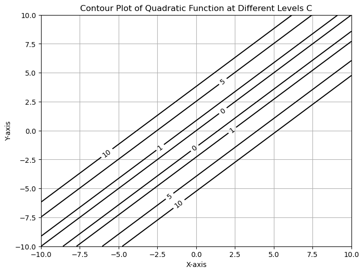

```python
# Generate evenly spaced sequences of numbers
x = np.linspace(-10, 10, num = 100)
y = np.linspace(-10, 10, num = 100)

x, y = np.meshgrid(x, y)

# Example case c, alpha > 0, beta = 0, we will use alpha = 2, beta = 0
f_of_x_y  = problem_2_new_quad_func(x, y, alpha=2,beta = 0)
f_of_x_y

# Create a contour plot
plt.figure(figsize=(8, 6))
contour = plt.contour(x, y, f_of_x_y, levels=levels, colors='k')
plt.clabel(contour, inline=1, fontsize=10)

# Add labels, title, and a color bar
plt.xlabel('X-axis')
plt.ylabel('Y-axis')
plt.title('Contour Plot of Quadratic Function at Different Levels C')
#plt.colorbar()

# Show the plot
plt.grid(True)
plt.show()
```

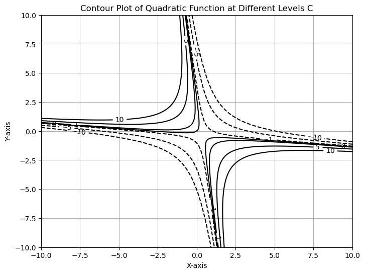

```python
# Generate evenly spaced sequences of numbers
x = np.linspace(-10, 10, num = 100)
y = np.linspace(-10, 10, num = 100)

x, y = np.meshgrid(x, y)

# Example case d, alpha > 0, beta < 0, we will use alpha = 2, beta = -3
f_of_x_y  = problem_2_new_quad_func(x, y, alpha=2,beta = -3)
f_of_x_y

# Create a contour plot
plt.figure(figsize=(8, 6))
contour = plt.contour(x, y, f_of_x_y, levels=levels, colors='k')
plt.clabel(contour, inline=1, fontsize=10)

# Add labels, title, and a color bar
plt.xlabel('X-axis')
plt.ylabel('Y-axis')
plt.title('Contour Plot of Quadratic Function at Different Levels C')

# Show the plot
plt.grid(True)
plt.show()
```

## Problem 3

Prove that if the function $f: \mathbb{R}^n \rightarrow \mathbb{R}$ is differentialble, the gradient of $f$ at a point is either zero, or perpendicular to the level set of $f$ at that point.

We define the gradient of $f: \mathbb{R}^n \rightarrow \mathbb{R}$ as the following vector: $$ \begin{align*} \nabla f = \left(\frac{\partial f}{\partial x_1}, \frac{\partial f}{\partial x_2}, \ldots, \frac{\partial f}{\partial x_n}\right) \end{align*} $$ and level set $L(c) = \{x \in \mathbb{R}^n ; f(x) = c\}$ where $c = f(\gamma)$ and $\gamma$ is a point in $\mathbb{R}^n$.

For level set $L(c)$, we can define a vector $t$ which is tangent at point $\gamma$. The directional derivative of $f$ at this point $\gamma$ can be defined by the following dot product.

$$ \begin{align*} D_{\gamma}f &= \frac{\nabla f(\gamma) \ t}{||t||} \end{align*} $$

To show that two vectors are perpendicular, we must show their dot product equals zero.

$$ \begin{align*} 0 &= \frac{\nabla f(\gamma) \ t}{||t||} \end{align*} $$

The above can only be true when $t$ is the trivial $\vec{0}_n$, $\nabla f(\gamma) = 0$, or the vector $t$ is perpendicular to $\nabla f(\gamma)$ at point $\gamma$.

## Problem 4

Let function $f: \mathbb{R} \rightarrow \mathbb{R}$ be defined as $f(x) = x^2 - x^4$. Find all the stationary points. Next, characterize all the local and global minimizers of $f$.

Let's first visualize the plot:

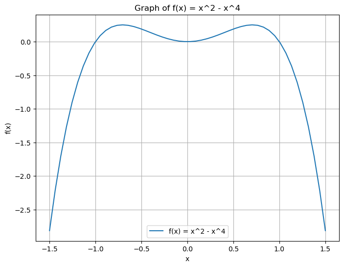

```python
# Define the function f(x)
def f(x):
    return x**2 - x**4

# Generate x values
x = np.linspace(-1.5, 1.5)  # Create 400 points between -2 and 2

# Calculate corresponding y values
y = f(x)

# Create the plot
plt.figure(figsize=(8, 6))
plt.plot(x, y, label='f(x) = x^2 - x^4')
plt.xlabel('x')
plt.ylabel('f(x)')
plt.title('Graph of f(x) = x^2 - x^4')
plt.grid(True)
plt.legend()
plt.show()
```

Finding the stationary points: $$ \begin{align*} f(x) &= x^2 - x^4 \\ f'(x) &= 2x - 4x^3 \\ 0 &= 2x(1 - 2x^2) \\ 0 = 2x \ &\text{and} \ 0 = 1 - 2x^2 \\ 0 = x \ &\text{and} \ x = \pm \sqrt{\frac{1}{2}} \\ \end{align*} $$

We can find the second derivative for minima: $$ \begin{align*} f''(x) &= 2 - 12x^2 \\ f''(0) &= 2 \\ f''(\sqrt{\frac{1}{2}}), f''(-\sqrt{\frac{1}{2}}) &= -4 \\ \end{align*} $$

## Problem 5

For the functions define below, find the smallest (or reasonably close to smallest) Lipschitz constant $L$ (if it exists). Prove your answer.

- (a) $f(x) = min(|x|, 5)$

For f(x), we must observe three cases of the domain. When $x \leq -5$ or $x \geq5$, the output of the function will be 5. When $ -5 < x < 5$, $f(x)$ will be equal to the value of $|x|$. Since $\frac{d}{dx}|x| = 1$ when $x>0$ and $\frac{d}{dx}|x| = -1$ when $x<0$, we have the Lipschitz constant equal to 1. Thus for this function, $L = 1$.

- (b) $f(x) = 5x^2 - 3x + 4$ on $\Omega = [-4, 4]$.

$$ \begin{align*} f'(x) &= 10x - 3 \\ |f'(-4)| &= 10(-4) - 3 = |-43| = 43 |f'(4)| &= 10(4) - 3 = |37| = 37 \end{align*} $$

We also need to check any critical points.

$$ \begin{align*} f'(x) &= 10x - 3 \\ 0 &= 10x - 3 \\ x &= \frac{3}{10} \\ \end{align*} $$

- (c) $f(x) = exp(x)$

Since this function is always increasing on an unbounded domain, the Lipshitz constant does not exist.

- (d) $f(x) = log(1+ \frac{x}{4}) - \sin(x) \ \text{on} \ \Omega = [-2, 8]$

$$ \begin{align*} f'(x) &= \frac{1}{4} * \frac{1}{1 + \frac{x}{4}} - \cos(x) \\ &= \frac{1}{4 + x} - \cos(x) \\ 0 &= \frac{1}{4 + x} - \cos(x) \\ \end{align*} $$

```
The maximum value of the derivative is at the point: ( 3.112781954887218 , 1.1401769667007668 ).
```

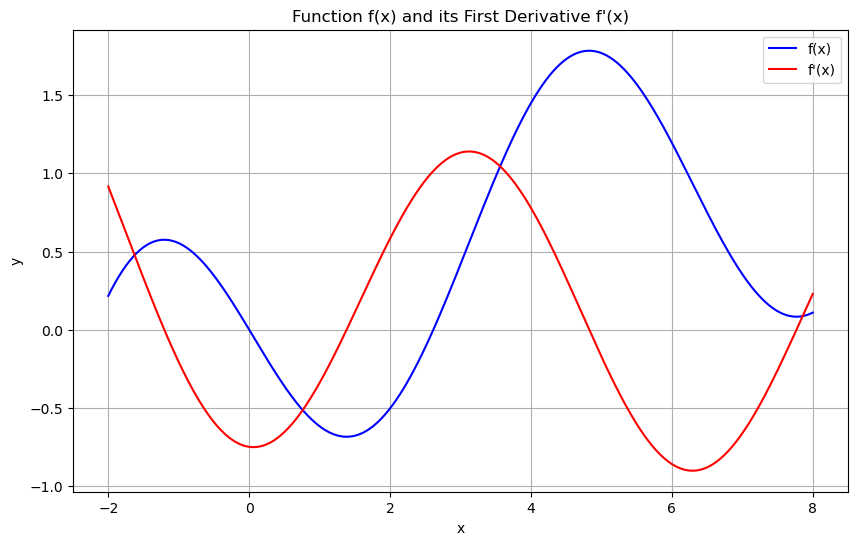

```python
# Define the function f(x)
def f(x):
    return np.log(1 + x/4) - np.sin(x)

# Define the derivative of f(x)
def f_prime(x):
    return 1 / (4 * (1 + x/4)) - np.cos(x)

# Attempt at taylor approximation, does not work very well
def f_prime_approx(x):
    return  (1 / (4 + x)) - (1 - x**2/2 + x**4/24- x**6/720 + x**8/40320)

# Generate x values
x = np.linspace(-2, 8, 400)  # Creating 400 evenly spaced points between -2 and 8

# Calculate the corresponding values of f(x) and f'(x)
y = f(x)
y_prime = f_prime(x)
#y_prime_approx = f_prime_approx(x)

# Find the maximum point
max_x = x[np.argmax(y_prime)]
max_y = np.max(y_prime)

# Tell us where max coordinate is:
print("The maximum value of the derivative is at the point: (", max_x, ",", max_y, ").")

# Create a plot
plt.figure(figsize=(10, 6))

# Plot f(x)
plt.plot(x, y, label='f(x)', color='blue')

# Plot f'(x)
plt.plot(x, y_prime, label="f'(x)", color='red')

# Now we plot f'(x) approximation using a Taylor approximation
#plt.plot(x, y_prime_approx, label = "f'(x) approx", color = "green")

# Add labels and legend
plt.xlabel('x')
plt.ylabel('y')
plt.legend()

# Show the plot
plt.title('Function f(x) and its First Derivative f\'(x)')
plt.grid(True)
plt.show()
```

```python
f_prime(np.pi)
```

```
1.1400247883778893
```

From the graph above, we can see the maximizing point is when $x \approx \pi$ giving us a Lipschitz constant of $\approx 1.14$

## Problem 6

```python
def function(n):
    i = 1
    while (i <= n):
        j = 1
        while (j <=n):
            g(i,j)

            k =1
            while (k <= n):
                h(i, j, k)
                k = k*3
            j = j+i
        i = i +1
```

For the function $g$, we have the first while loop goes from $i = 1 \ldots n$. However, we must consider the second loop more carefully, since the updating step of $j$ is dependent on $i$.

- When $i = 1$, second loop is executed $n$ times. when $i = 2$, the second loop is only executed $\frac{n}{2}$ times, $i=3$ corresponds to $\frac{n}{3}$ times and so on. This pattern is identical to that of a harmonic series, which asymptotically converges to $\log(n)$ Thus the first two loops are $O(n \log(n))$ for the function $g$.
- For the function $h$, $k$ is always being multiplied by 3 until it is less than or equal to $n$. Since $k=1$ at initialization, we can solve the following for the $l$ amount of loops:

$$ \begin{align*} n &= 3^l \\ \log(n) &= l \log(3) \\ \frac{\log(n)}{\log(3)} &= l \\ \end{align*} $$

Since $\log(3)$, we have the function $h$ has time complexity $O(\log(n))$, leaving for a total time complexity for the entire function as $O(n \log^2(n))$.